# Homework 3 - Coding

## (a)

Under the assumption that $d = 1$ and $n = 1$, the sample is then of size 1 and boils down to just $(x,y)$. The function $F$ writes simply as:

$$F(\beta) = \text{log}(1+\text{exp}(-yx\beta))+\lambda\beta^2$$

The gradient $\nabla F$ of $F$ is then given by:

$$\nabla F(\beta) = \frac{-yx\text{exp}(-yx\beta)}{1+\text{exp}(-yx\beta)}+2\lambda\beta$$

## (b)

Now, under the assumption that $d > 1$ and $n > 1$ the gradient $\nabla F$ of $F$ is given by:

$$\nabla F(\beta) = -\frac{1}{n}XQY + 2\lambda\beta$$

With $X$ and $Y$ corresponding to the $d x n$ and $1 x n$ predictor and response matrices respectively, and $Q$ given by:

$$Q = \text{Diag}([1-p_1,...,1-p_n])$$

With:

$$1-p_i = \frac{\text{exp}(-y_ix_i^T\beta)}{1+\text{exp}(-y_ix_i^T\beta)}$$

## (c)

```python
import pandas as pd
import numpy as np
import math
import matplotlib.pyplot as plt

from sklearn.model_selection import train_test_split
from sklearn import preprocessing
from sklearn.linear_model import LogisticRegression
from sklearn.linear_model import LogisticRegressionCV
```

```python
# Read in data, examine head

file = 'https://raw.githubusercontent.com/JWarmenhoven/ISLR-python/master/Notebooks/Data/Smarket.csv'
smarket = pd.read_csv(file, sep=',', header=0, index_col=0)

smarket.head()
```

|  | Year | Lag1 | Lag2 | Lag3 | Lag4 | Lag5 | Volume | Today | Direction |
| --- | --- | --- | --- | --- | --- | --- | --- | --- | --- |
| 1 | 2001 | 0.381 | -0.192 | -2.624 | -1.055 | 5.010 | 1.1913 | 0.959 | Up |
| 2 | 2001 | 0.959 | 0.381 | -0.192 | -2.624 | -1.055 | 1.2965 | 1.032 | Up |
| 3 | 2001 | 1.032 | 0.959 | 0.381 | -0.192 | -2.624 | 1.4112 | -0.623 | Down |
| 4 | 2001 | -0.623 | 1.032 | 0.959 | 0.381 | -0.192 | 1.2760 | 0.614 | Up |
| 5 | 2001 | 0.614 | -0.623 | 1.032 | 0.959 | 0.381 | 1.2057 | 0.213 | Up |

## (d)

```python
# Convert response variable from categorical to binary numerical, select features

y = np.array([1 if x == 'Up' else -1 for x in smarket['Direction']])
X = np.array(smarket[['Lag1', 'Lag2', 'Volume']])
```

```python
# Create train/test split

X_train, X_test, y_train, y_test = train_test_split(X, y, test_size=0.2, random_state=0)

print('Number of samples in train set:', len(y_train))
print('Number of samples in test set:', len(y_test))
```

```
Number of samples in train set: 1000
Number of samples in test set: 250
```

```python
# Standardize features

scaler = preprocessing.StandardScaler().fit(X_train)
X_train = scaler.transform(X_train)
X_test = scaler.transform(X_test)
```

## (e)

```python
# Define compute_grad function

def compute_grad(beta, X, y, lam):
    n = len(y)
    q_list = []
    for i in range(n):
        x_tb = np.dot(np.transpose(X[i]), beta)
        q_list.append(math.exp(-y[i]*x_tb)/(1+math.exp(-y[i]*x_tb)))
    Q = np.diag(np.array(q_list))
    return -1/n*np.dot(np.dot(np.transpose(X), Q),y)+2*lam*beta
```

## (f)

```python
# Define objective function

def obj_fun(beta, X, y, lam):
    n = len(y)
    loss_sum = 0
    for i in range(n):
        x_tb = np.dot(np.transpose(X[i]), beta)
        loss_sum += math.log(1+math.exp(-y[i]*x_tb))
    return loss_sum/n+lam*np.dot(np.transpose(beta), beta)
```

```python
# Define backtracking function

def backtracking(eta_init, decay_rate, prop_constant, beta, X, y, lam):
    eta = eta_init

    def sufficient_decrease(eta):
        grad = compute_grad(beta, X, y, lam)
        return (obj_fun(beta-eta*grad, X, y, lam)-obj_fun(beta, X, y, lam)) <= \
                (prop_constant*eta*np.dot(np.transpose(grad), -grad))

    while not sufficient_decrease(eta):
        eta *= decay_rate

    return eta
```

## (g)

```python
# Define gradient descent function with backtracking

def grad_descent(beta_init, step_size, epsilon, X, y, lam, decay_rate, prop_constant):
    iterates = []
    beta = beta_init
    grad = compute_grad(beta, X, y, lam)
    while np.linalg.norm(grad) > epsilon:
        step_size = backtracking(step_size, decay_rate, prop_constant, beta, X, y, lam)
        new_beta = beta - step_size*compute_grad(beta, X, y, lam)
        iterates.append(new_beta)
        beta = new_beta
        grad = compute_grad(beta, X, y, lam)
    return iterates
```

## (h)

```python
# Define fast grad descent algorithm with backtracking

def fast_grad_algo(step_size, epsilon, X, y, lam, decay_rate, prop_constant):
    iterates = []
    beta = np.zeros(X.shape[1])
    theta = np.zeros(X.shape[1])
    grad = compute_grad(beta, X, y, lam)
    steps = 0
    while np.linalg.norm(grad) > epsilon:
        step_size = backtracking(step_size, decay_rate, prop_constant, beta, X, y, lam)
        new_beta = theta - step_size*compute_grad(theta, X, y, lam)
        theta = new_beta + steps/(steps+3)*(new_beta-beta)
        iterates.append(new_beta)
        beta = new_beta
        grad = compute_grad(beta, X, y, lam)
        steps += 1
    return iterates
```

## (i)

```python
# Specify hyper-parameters

step_size_init = 0.1
target_accuracy = 1*10**-5
beta_init = np.zeros(X_train.shape[1])
lam = 0.5
decay_rate = 0.5
prop_constant = 0.5
```

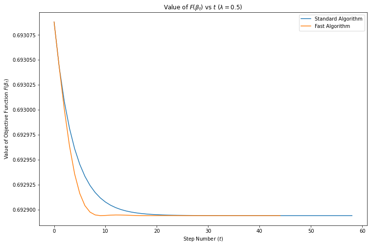

```python
# Perform gradient descent using standard methods + backtracking vs fast gradient descent with backtracking,
# plot results

grad_iterates = grad_descent(beta_init, step_size_init, target_accuracy, \
                             X_train, y_train, lam, decay_rate, prop_constant)

fast_grad_iterates = fast_grad_algo(step_size_init, target_accuracy, X_train, y_train, lam, decay_rate, prop_constant)


slow_points = []
fast_points = []

for i in range(len(grad_iterates)):
    slow_points.append(obj_fun(grad_iterates[i], X_train, y_train, lam))

for i in range(len(fast_grad_iterates)):
    fast_points.append(obj_fun(fast_grad_iterates[i], X_train, y_train, lam))

f = plt.figure(figsize = (12,8))
plt.xlabel('Step Number ($t$)')
plt.ylabel(r'Value of Objective Function $F(\beta_t)$')
plt.title(r'Value of $F(\beta_t)$ vs $t$ ($\lambda=0.5$)')
plt.plot(slow_points)
plt.plot(fast_points)
plt.legend(['Standard Algorithm', 'Fast Algorithm'])
```

```python
# Print number of iterations for each algorithm (for fun!)

print('Number of iterations required for gradient descent:', len(grad_iterates))
print('Number of iterations required for fast gradient descent:', len(fast_grad_iterates))
```

```
Number of iterations required for gradient descent: 59
Number of iterations required for fast gradient descent: 45
```

In the figure above we can see that the fast gradient descent algorithm approaches the minimum of the objective function much quicker than the standard gradient descent algorithm. It is interesting, however, that the fast gradient descent algorithm does not appear to be monotonically decreasing.

## (j)

```python
# Define sk_learn's objective function

def obj_fun_sk(beta, X, y, C):
    n = len(y)
    loss_sum = 0
    for i in range(n):
        x_tb = np.dot(np.transpose(X[i]), beta)
        loss_sum += math.log(1+math.exp(-y[i]*x_tb))
    return C*loss_sum+1/2*np.dot(np.transpose(beta), beta)
```

```python
# Instantiate and train log model, print out comparison of coefficients

log_model = LogisticRegression(tol=target_accuracy, C=1/len(y_train)).fit(X_train, y_train)

print('Coefficients from Trevor\'s implementation:\n', fast_grad_iterates[-1])
print('\nCoefficients from sklearn\'s implementation:\n', log_model.coef_[0])
```

```
Coefficients from Trevor's implementation:
 [-0.01412273 -0.01258201  0.00702339]

Coefficients from sklearn's implementation:
 [-0.01412958 -0.01258723  0.00702674]
```

```python
# Compare objective function's value

print('Objective Function Value for Trevor\'s implementation:\n',
      obj_fun(fast_grad_iterates[-1], X_train, y_train, lam))
print('\nObjective Function Value for sklearn\'s implementation:\n',
      obj_fun_sk(log_model.coef_[0], X_train, y_train, 1/(1/2/lam*len(y_train))))
```

```
Objective Function Value for Trevor's implementation:
 0.6928938553336433

Objective Function Value for sklearn's implementation:
 0.6928938553675781
```

As can be seen above, both the coefficients and the objective function's value at those coefficients are very close between the two implementations. This makes sense as the objective functions are the same (assuming I scaled correctly) and therefore both optimizations will produce the same result.

## (k)

```python
# Run stratified k fold cross validation on dataset over a large range of C values,
# save optimal value for conversion into a lambda value

cross_val_mod = LogisticRegressionCV(tol=target_accuracy, Cs=20).fit(X_train, y_train)

optimal_C = cross_val_mod.C_[0]
```

```python
# Convert optimal C into optimal lambda, print for fun!

optimal_lambda = optimal_C*len(y_train)
print('Optimal lambda:', optimal_lambda)
```

```
Optimal lambda: 12.742749857031335
```

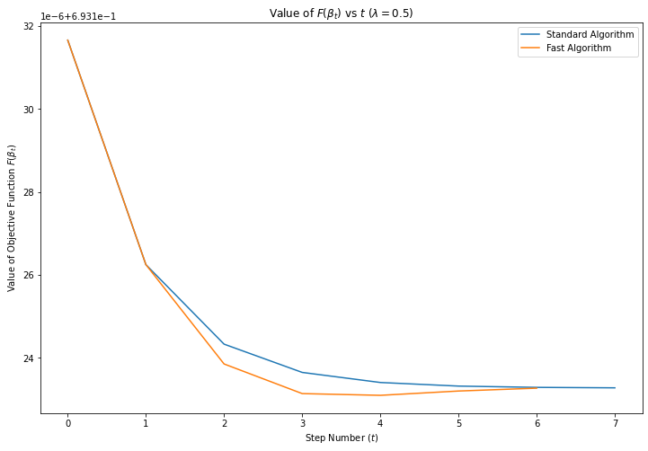

```python
# Perform gradient descent using standard methods + backtracking vs fast gradient descent with backtracking
# using optimal lambda, plot results

grad_iterates = grad_descent(beta_init, step_size_init, target_accuracy, \
                             X_train, y_train, optimal_lambda, decay_rate, prop_constant)

fast_grad_iterates = fast_grad_algo(step_size_init, target_accuracy, \
                                    X_train, y_train, optimal_lambda, decay_rate, prop_constant)


slow_points = []
fast_points = []

for i in range(len(grad_iterates)):
    slow_points.append(obj_fun(grad_iterates[i], X_train, y_train, lam))

for i in range(len(fast_grad_iterates)):
    fast_points.append(obj_fun(fast_grad_iterates[i], X_train, y_train, lam))

f = plt.figure(figsize = (12,8))
plt.xlabel('Step Number ($t$)')
plt.ylabel(r'Value of Objective Function $F(\beta_t)$')
plt.title(r'Value of $F(\beta_t)$ vs $t$ ($\lambda=0.5$)')
plt.plot(slow_points)
plt.plot(fast_points)
plt.legend(['Standard Algorithm', 'Fast Algorithm'])
```

```python
# Compute accuracy on given coefficients, features, and labels

def compute_accuracy(beta, X, y):
    x_tb = x_tb = np.dot(X, beta)
    probs_down = 1-1/(1+np.exp(-x_tb))
    preds = [-1 if i > .5 else 1 for i in probs_down]
    return sum(preds == y)/len(y)
```

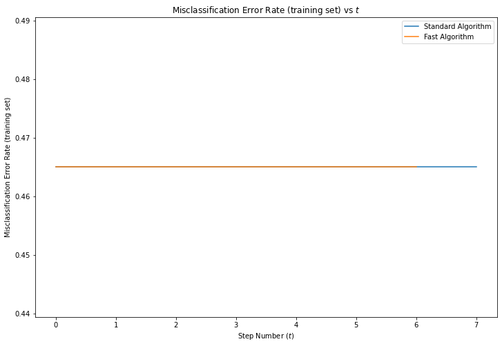

```python
# Calculate and plot training set misclassification error rate across the iterates
# of each gradient descent algorithm


slow_error_rate = []
fast_error_rate = []

for i in range(len(grad_iterates)):
    slow_error_rate.append(1-compute_accuracy(grad_iterates[i], X_train, y_train))

for i in range(len(fast_grad_iterates)):
    fast_error_rate.append(1-compute_accuracy(fast_grad_iterates[i], X_train, y_train))

f = plt.figure(figsize = (12,8))
plt.xlabel('Step Number ($t$)')
plt.ylabel('Misclassification Error Rate (training set)')
plt.title(r'Misclassification Error Rate (training set) vs $t$')
plt.plot(slow_error_rate)
plt.plot(fast_error_rate)
plt.legend(['Standard Algorithm', 'Fast Algorithm'])
```

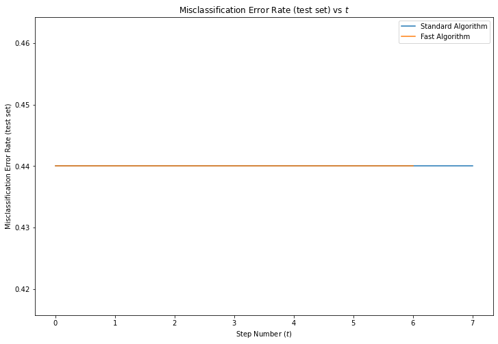

```python
# Calculate and plot test set misclassification error rate across the iterates
# of each gradient descent algorithm

slow_error_rate = []
fast_error_rate = []

for i in range(len(grad_iterates)):
    slow_error_rate.append(1-compute_accuracy(grad_iterates[i], X_test, y_test))

for i in range(len(fast_grad_iterates)):
    fast_error_rate.append(1-compute_accuracy(fast_grad_iterates[i], X_test, y_test))

f = plt.figure(figsize = (12,8))
plt.xlabel('Step Number ($t$)')
plt.ylabel('Misclassification Error Rate (test set)')
plt.title(r'Misclassification Error Rate (test set) vs $t$')
plt.plot(slow_error_rate)
plt.plot(fast_error_rate)
plt.legend(['Standard Algorithm', 'Fast Algorithm'])
```

As can be seen in the two plots above, our misclassification error rate across the iterates of both the standard gradient descent and the fast gradient descent have extremely low (computationally-speaking, 0) variance! At first, I found this alarming. However, going back to the objective function we were minimizing it's plain to see that the iterates were producing an incredibly small amount of change (on the order of 1e-6) to the objective function with each iteration. Because our objective function was close to being a flat function, our "optimazation" of $\beta$ produced minimal change in the misclassification error of our model.